# Questionnaire Report for Haddock

(MERA version 4.1.6)

Abdul Ben-Hasan (abenhasan@gmail.com)

2019-05-01

# 1 About this document

This is a prototype of an automatic report that documents how the user specified the operating model and their various justifications.

# 2 Introduction

1. Describe the history and current status of the fishery, including fleets, sectors, vessel types and practices/gear by vessel type, landing ports, economics/markets, whether targeted/bycatch, other stocks caught in the fishery. (from assessment report: file:///C:/Users/abenh/Desktop/Faroe%20Islands%20haddock%20-%20SA%20report%2014.12.2016%20Final.pdf) “The fishery is a mixed cod-haddock and saithe fishery where cod is the most important species. The fishery takes place both in the Norwegian, the Svalbard as well as in the Russian fishing zones of the Barents Sea. The dominating gears are bottom trawl (68%) and long line (12 %) the remaining 20% is taken by a mixture of gears including gill nets, jiggings a.o., ICES (2016) . Recent catches are slightly below 200 kt, Figure 2. Management is based on a management plan agreed between Norway and Russia in the Joint Norwegian-Russian Fisheries Commission (JNRFC) and implemented in Norwegian and Russian legislation. The haddock stock as is the cod stocks are at very high level. Haddock is subject to annual analytical age-based assessments with appropriate biological reference points being set, and are subject to an internationally agreed management plan and harvest control rule. Reference points have been defined and tested by ICES; ICES considers both the plans and the control rules to be consistent with both the precautionary and MSY-framework approaches. The spawning stock biomass of haddock is currently above biological reference levels and ICES considers the haddock stock to retain full reproductive capacity (ICES, 2016).”
2. Describe the stock’s ecosystem functions, dependencies, and habitat types. (from https://www.fishbase.se/TrophicEco/EcosysRef.php?ecosysname=Faroe+Plateau&ve_code=228) “The relatively broad shelf surrounding the Faeroe Islands in the northeast Atlantic Ocean comprises the Faeroe Plateau LME. The islands and their shelf are affected by a branch of the North Atlantic Drift current, which flows north through this area. Commercial stocks inhabiting this LME include cod, herring, and capelin; the area also serves as important feeding grounds for pilot whales and other marine mammals.”
3. Provide all relevant reference materials, such as assessments, research, and other analysis. Assessment report: file:///C:/Users/abenh/Desktop/Faroe%20Islands%20haddock%20-%20SA%20report%2014.12.2016%20Final.pdf FishBase: https://www.fishbase.se Assessment report: http://www.ices.dk/sites/pub/Publication%20Reports/Expert%20Group%20Report/acom/2017/NWWG/07-NWWG%20Report%202017%20Sec%2005%20Faroe%20haddock.pdf Paper: https://academic.oup.com/icesjms/article/64/4/730/642865 Report: http://cdn.lms.fo/media/3541/fo_fisheries_and_aquaculture_final_revised.pdf Assessment report: http://www.ices.dk/sites/pub/Publication%20Reports/Advice/2018/Special_requests/neafc.2018.31b.pdf

# 3 Fishery Characteristics

## 3.1 Longevity

| Answered |
| --- |
| Very short-lived (5 < maximum age < 7) |
| Short-lived (7 < maximum age < 10) |
| Moderate life span (10 < maximum age < 20) |
| Moderately long-lived (20 < maximum age < 40) |
| Long-lived (40 < maximum age < 80) |
| Very long-lived (80 < maximum age < 160) |

[output not shown]

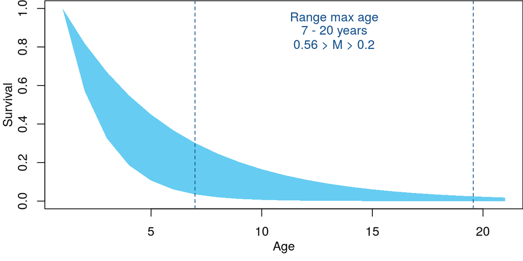

## 3.2 Stock depletion

| Answered |
| --- |
| Crashed (D < 0.05) |
| Very depleted (0.05 < D < 0.1) |
| Depleted (0.1 < D < 0.15) |
| Moderately depleted (0.15 < D < 0.3) |
| Healthy (0.3 < D < 0.5) |
| Underexploited (0.5 < D) |

[output not shown]

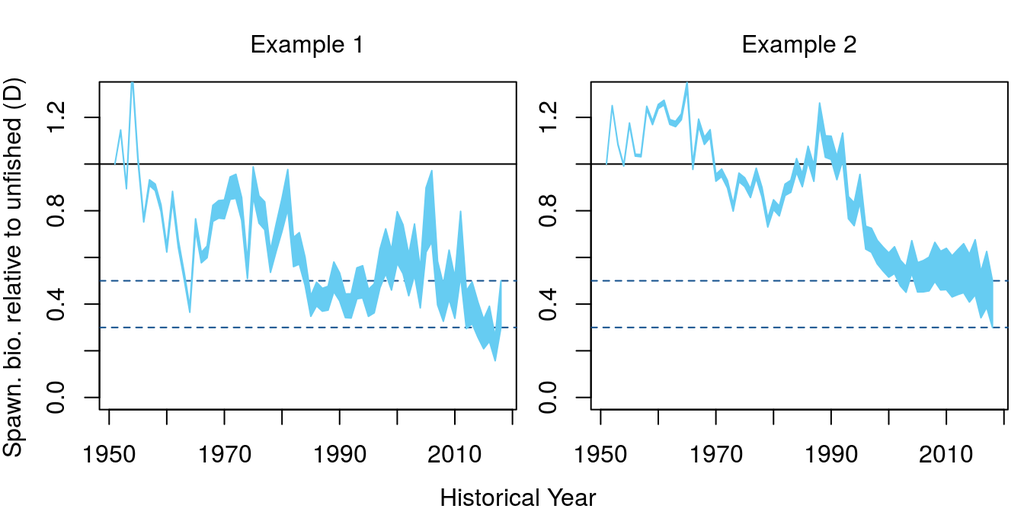

## 3.3 Resilence

| Answered |
| --- |
| Not resilient (steepness < 0.3) |
| Low resilience (0.3 < steepness < 0.5) |
| Moderate resilence (0.5 < steepness < 0.7) |
| Resilient (0.7 < steepness < 0.9) |
| Very Resilient (0.9 < steepness) |

| Justification |
| --- |
| No information about steepness was provided in the assessment reports. |

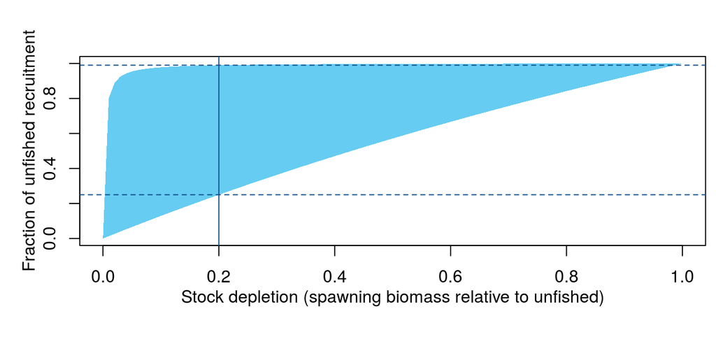

## 3.4 Historical effort pattern

| Answered |
| --- |
| Stable |
| Two-phase |
| Boom-bust |
| Gradual increases |
| Stable, recent increases |
| Stable, recent declines |

| Justification |
| --- |
| Figure 2b in the paper: https://academic.oup.com/icesjms/article/64/4/730/642865 |

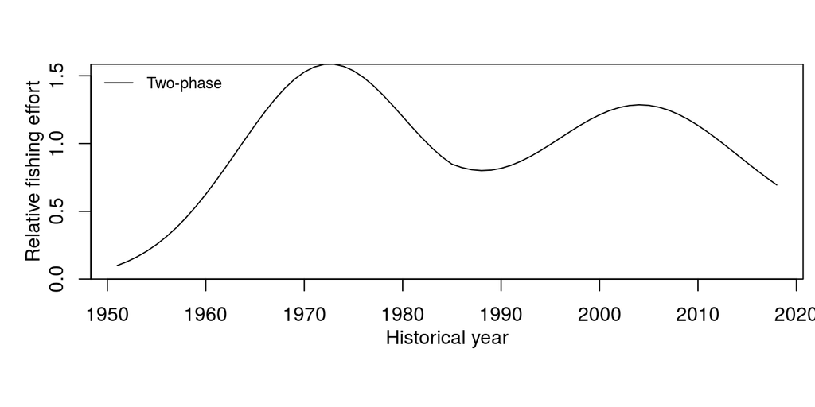

## 3.5 Inter-annual variability in historical effort

| Answered |
| --- |
| Not variable (less than 20% inter-annual change (IAC)) |
| Variable (maximum IAC between 20% to 50%) |
| Highly variable (maximum IAC between 50% and 100%) |

| Justification |
| --- |
| Figure 2b in the paper: https://academic.oup.com/icesjms/article/64/4/730/642865 |

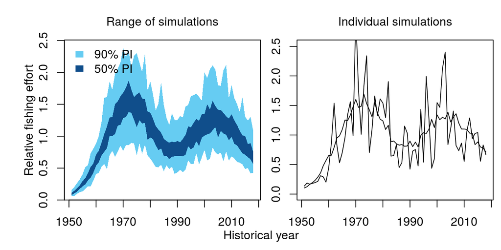

## 3.6 Historical fishing efficiency changes

| Answered |
| --- |
| Declining by 2-3% pa (halves every 25-35 years) |
| Declining by 1-2% pa (halves every 35-70 years) |
| Stable -1% to 1% pa (may halve/double every 70 years) |
| Increasing by 1-2% pa (doubles every 35-70 years) |
| Increasing by 2-3% pa (doubles every 25-35 years) |

[output not shown]

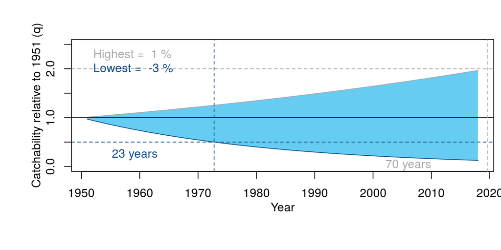

## 3.7 Future fishing efficiency changes

| Answered |
| --- |
| Declining by 2-3% pa (halves every 25-35 years) |
| Declining by 1-2% pa (halves every 35-70 years) |
| Stable -1% to 1% pa (may halve/double every 70 years) |
| Increasing by 1-2% pa (doubles every 35-70 years) |
| Increasing by 2-3% pa (doubles every 25-35 years) |

| Justification |
| --- |
| Highly uncertain (see the paper: https://academic.oup.com/icesjms/article/64/4/730/642865) |

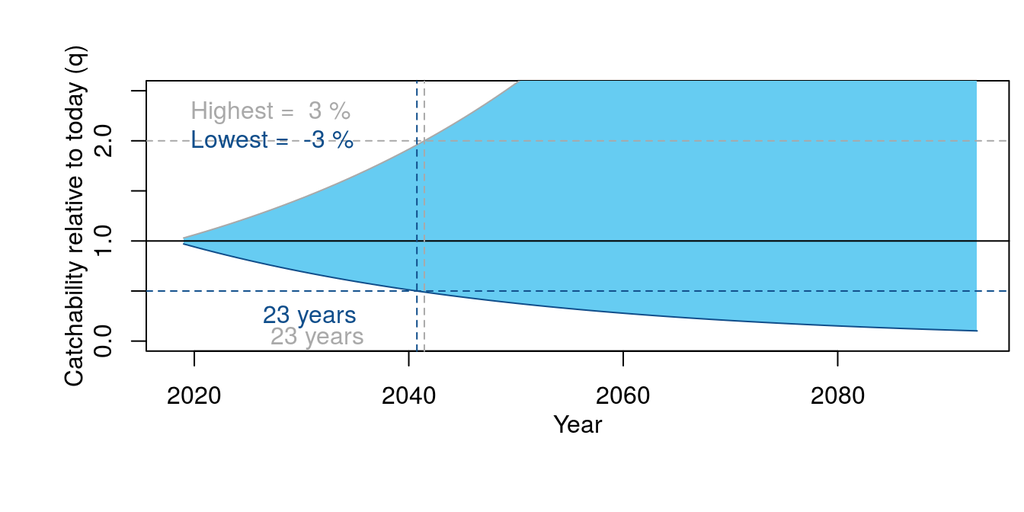

## 3.8 Length at maturity

| Answered |
| --- |
| Very small (0.4 < LM < 0.5) |
| Small (0.5 < LM < 0.6) |
| Moderate (0.6 < LM < 0.7) |
| Moderate to large (0.7 < LM < 0.8) |
| Large (0.8 < LM < 0.9) |

[output not shown]

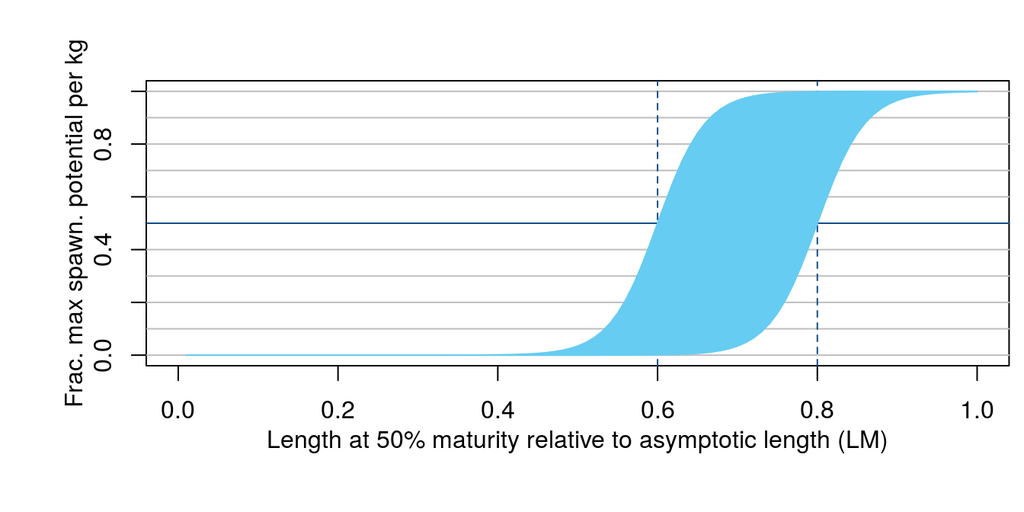

## 3.9 Selectivity of small fish

| Answered |
| --- |
| Very small (0.1 < S < 0.2) |
| Small (0.2 < S < 0.4) |
| Half asymptotic length (0.4 < S < 0.6) |
| Large (0.6 < S < 0.8) |
| Very large (0.8 < S < 0.9) |

Justification

Catch at age numbers for the year 2017 roughly indicate that age 3 is the length at 50% selectivity. Plugging that age into von Bertalanffy growth equation (and omitting asymptotic length term from the equation), I get the answer chose above (Table 5.4 in assessment report: http://www.ices.dk/sites/pub/Publication%20Reports/Expert%20Group%20Report/acom/2018/NWWG/01%20NWWG%20Report%202018.pdf). von Bertalanffy parameters for haddock were obtained from FishBase.

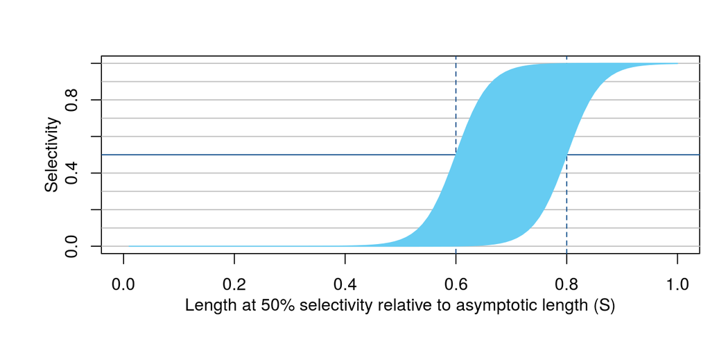

## 3.10 Selectivity of large fish

| Answered |
| --- |
| Asymptotic selectivity (SL = 1) |
| Declining selectivity with length (0.75 < SL < 1) |
| Dome-shaped selectivity (0.25 < SL < 0.75) |
| Strong dome-shaped selectivity (SL < 0.25) |

| Justification |
| --- |
| No information was found to determine a sensible range of the selectivity for large fish |

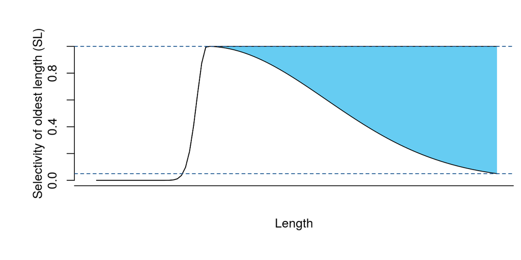

## 3.11 Discard rate

| Answered |
| --- |
| Low (DR < 1%) |
| Low - moderate (1% < DR < 10%) |
| Moderate (10% < DR < 30%) |
| Moderate - high (30% < DR < 50%) |
| High (50% < DR < 70%) |

[output not shown]

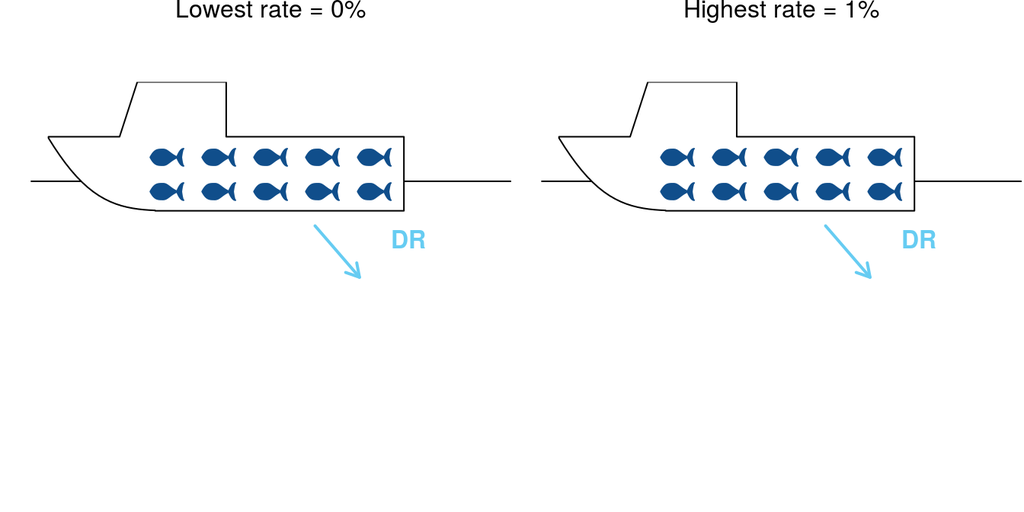

## 3.12 Post-release mortality rate

| Answered |
| --- |
| Low (PRM < 5%) |
| Low - moderate (5% < PRM < 25%) |
| Moderate (25% < PRM < 50%) |
| Moderate - high (50% < PRM < 75%) |
| High (75% < PRM < 95%) |
| Almost all die (95% < PRM < 100%) |

[output not shown]

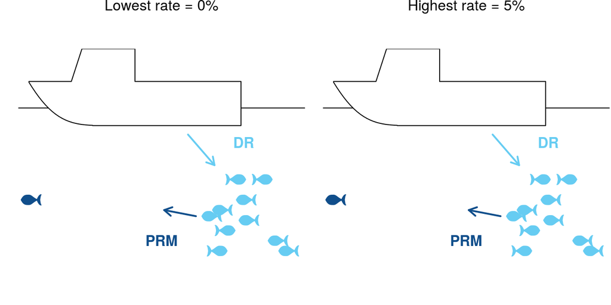

## 3.13 Recruitment variability

| Answered |
| --- |
| Very low (less than 10% inter-annual changes (IAC)) |
| Low (max IAC of between 20% and 60%) |
| Moderate (max IAC of between 60% and 120%) |
| High (max IAC of between 120% and 180%) |
| Very high (max IAC greater than 180%) |

| Justification |
| --- |
| No information was found to determine a sensible range of recruitment variability |

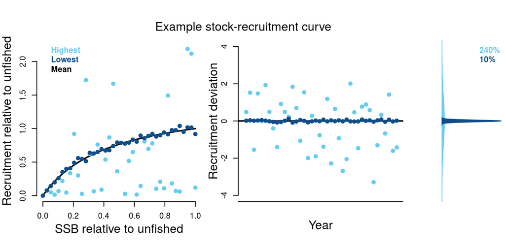

## 3.14 Size of an existing MPA

| Answered |
| --- |
| None |
| Small (A < 5%) |
| Small-moderate (5% < A < 10%) |
| Moderate (10% < A < 20%) |
| Large (20% < A < 30%) |
| Very large (30% < A < 40%) |
| Huge (40% < A < 50%) |

Justification

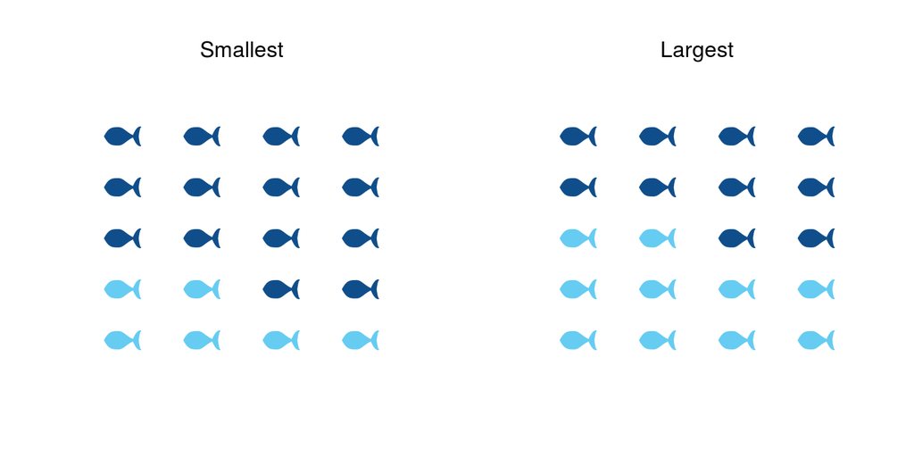

## 3.15 Spatial mixing (movement) in/out of existing MPA

| Answered |
| --- |
| Very low (P < 1%) |
| Low (1% < P < 5%) |
| Moderate (5% < P < 10%) |
| High (10% < P < 20%) |
| Fully mixed |

| Justification |
| --- |
| There is uncertainty regarding the movement of this stock. |

[figure not shown]

## 3.16 Size of a future potential MPA

| Answered |
| --- |
| None |
| Small (A < 5%) |
| Small-moderate (5% < A < 10%) |
| Moderate (10% < A < 20%) |
| Large (20% < A < 30%) |
| Very large (30% < A < 40%) |
| Huge (40% < A < 50%) |

| Justification |
| --- |
| No justification was provided |

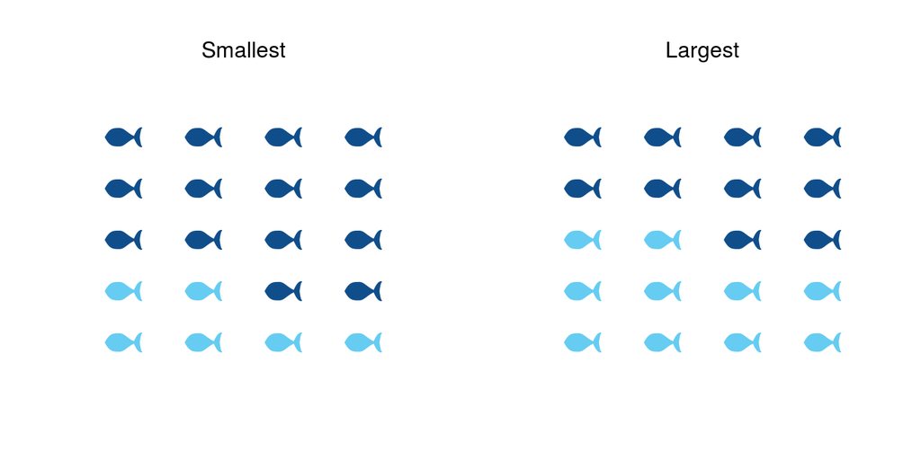

## 3.17 Spatial mixing (movement) in/out of future potential MPA

| Answered |
| --- |
| Very low (P < 1%) |
| Low (1% < P < 5%) |
| Moderate (5% < P < 10%) |
| High (10% < P < 20%) |
| Fully mixed |

| Justification |
| --- |
| No justification was provided |

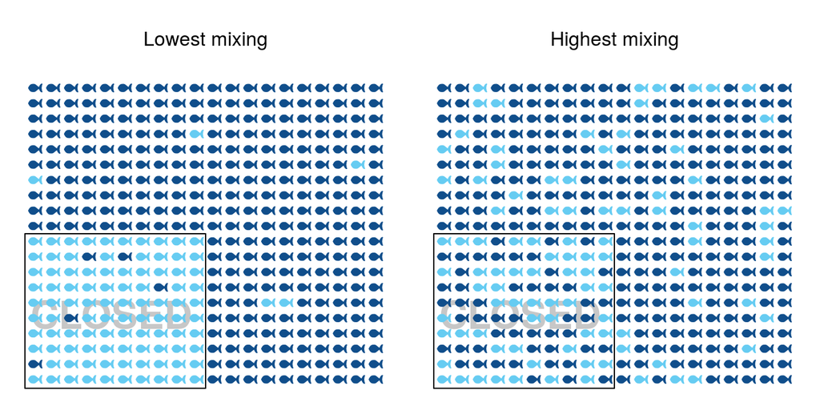

## 3.18 Initial stock depletion

| Answered |
| --- |
| Very low (0.1 < D1 < 0.15) |
| Low (0.15 < D1 < 0.3) |
| Moderate (0.3 < D < 0.5) |
| High (0.5 < D1) |
| Asymptotic unfished levels (D1 = 1) |

| Justification |
| --- |
| Unspecified by the assessment reports. |

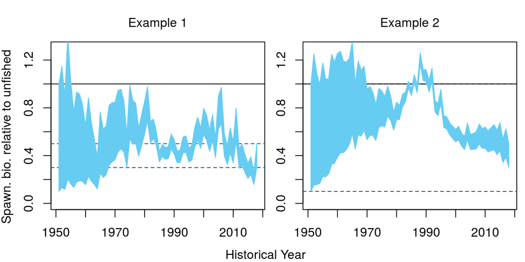

# 4 Management Characteristics

## 4.1 Types of fishery management that are possible

| Answered |
| --- |
| TAC (Total Allowable Catch): a catch limit |
| TAE (Total Allowable Effort): an effort limit |
| Size limit |
| Time-area closures (a marine reserve) |

Justification

1. Describe what, if any, current management measures are used to constrain catch/effort.  
(from assessment report: http://www.ices.dk/sites/pub/Publication%20Reports/Expert%20Group%20Report/acom/2018/NWWG/01%20NWWG%20Report%202018.pdf) “the fishery for haddock in 5.b is regulated  
through a maximum number of allocated fishing days, gear specifications, closed areas  
during spawning times, closed areas for longlining close to land and large areas closed  
to trawling. As a consequence, around 80% of the haddock landings derive from long  
line fisheries. Since the minimum mesh size in the trawls (codend) is 145 mm, the trawl  
catches consist of fewer small fish than the long line fisheries.”  
2. Describe historical management measures, if any.  
(from assessment report: http://www.ices.dk/sites/pub/Publication%20Reports/Expert%20Group%20Report/acom/2018/NWWG/01%20NWWG%20Report%202018.pdf) “Up to 1959, all vessels were allowed to fish around the Faroes outside the 3 nm zone.  
During the 1960s, the fisheries zone was gradually expanded, and in 1977 an EEZ of  
200 nm was introduced in the Faroe area. The demersal fishery by foreign nations has  
since decreased and Faroese vessels now take most of the catches. The fishery may be  
considered a multifleet and multispecies fishery as described below.”  
3. Describe main strengths and weaknesses of current monitoring and enforcement capacity.  
No information indicated in the assessment reports about monitoring and enforcement.  
4. Describe and reference any legal/policy requirements for management, monitoring and enforcement.  
No information indicated in the assessment reports

## 4.2 TAC offset: consistent overages/underages

| Answered |
| --- |
| Large underages (40% - 70% of recommended) |
| Underages (70% - 90% of recommended) |
| Slight underages (90% - 100% of recommended) |
| Taken exactly (95% - 105% of recommended) |
| Slight overages (100% - 110% of recommended) |
| Overages (110% - 150% of recommended) |
| Large overages (150% - 200% of recommended) |

| Justification |
| --- |
| No TAC imposed. |

[figure not shown]

## 4.3 TAC implementation variability

| Answered |
| --- |
| Constant (V < 1%) |
| Not variable (1% < V < 5%) |
| Low variability (5% < V < 10%) |
| Variable (10% < V < 20%) |
| Highly variable (20% < V < 40%) |

| Justification |
| --- |
| No justification was provided |

[figure not shown]

## 4.4 TAE offset: consistent overages/underages

| Answered |
| --- |
| Large underages (40% - 70% of recommended) |
| Underages (70% - 90% of recommended) |
| Slight underages (90% - 100% of recommended) |
| Taken exactly (95% - 105% of recommended) |
| Slight overages (100% - 110% of recommended) |
| Overages (110% - 150% of recommended) |
| Large overages (150% - 200% of recommended) |

| Justification |
| --- |
| TAE for Faroe haddock seems within the target TAE. |

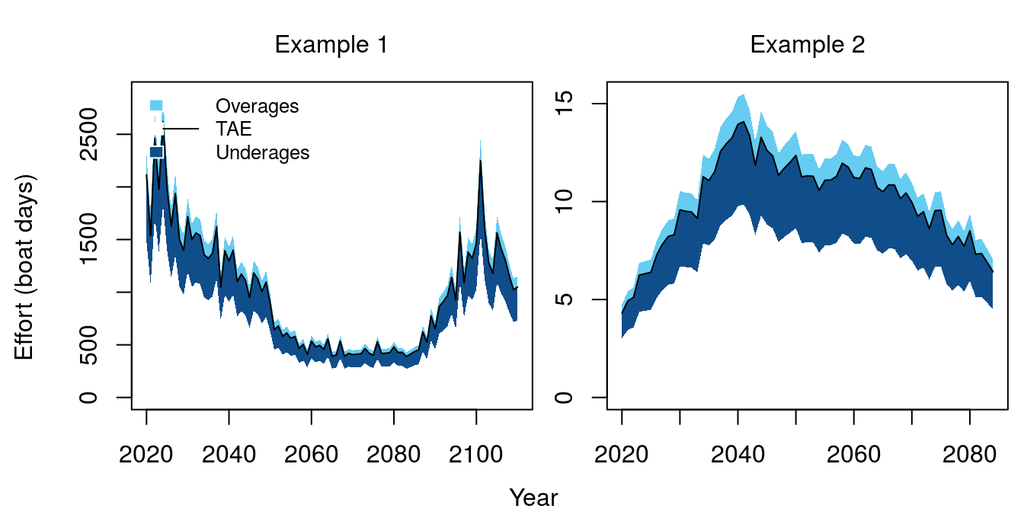

## 4.5 TAE implementation variability

| Answered |
| --- |
| Constant (V < 1%) |
| Not variable (1% < V < 5%) |
| Low variability (5% < V < 10%) |
| Variable (10% < V < 20%) |
| Highly variable (20% < V < 40%) |

| Justification |
| --- |
| There is high uncertainty in the variability of TAE implementation (see paper: https://academic.oup.com/icesjms/article/64/4/730/642865) |

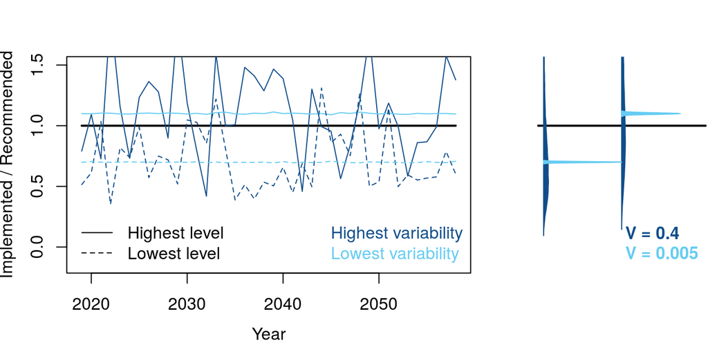

## 4.6 Size limit offset: consistent overages/underages

| Answered |
| --- |
| Much smaller (40% - 70% of recommended) |
| Smaller (70% - 90% of recommended) |
| Slightly smaller (90% - 100% of recommended) |
| Taken exactly (95% - 105% of recommended) |
| Slightly larger (100% - 110% of recommended) |
| Larger (110% - 150% of recommended) |
| Much larger (150% - 200% of recommended) |

| Justification |
| --- |
| No information provided regarding size limit offset. |

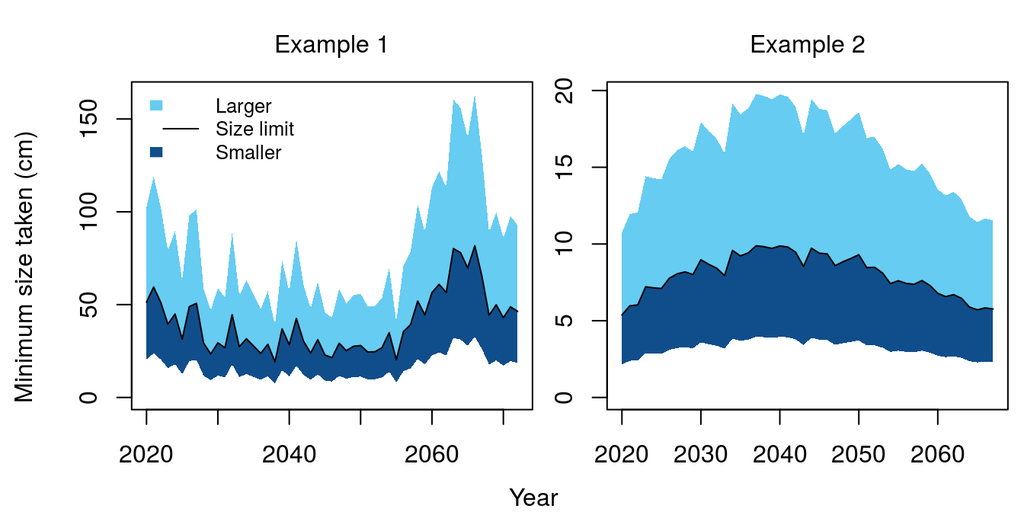

## 4.7 Size limit implementation variability

| Answered |
| --- |
| Constant (V < 1%) |
| Not variable (1% < V < 5%) |
| Low variability (5% < V < 10%) |
| Variable (10% < V < 20%) |
| Highly variable (20% < V < 40%) |

| Justification |
| --- |
| No justification was provided |

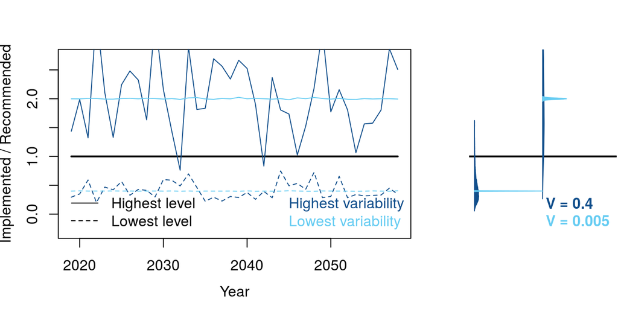

# 5 Data Characteristics

## 5.1 Available data types

| Answered |
| --- |
| Historical annual catches (from unfished) |
| Recent annual catches (at least 5 recent years) |
| Historical relative abundance index (from unfished) |
| Recent relative abundance index (at least 5 recent years) |
| Fishing effort |
| Size composition (length samples) |
| Age composition (age samples) |
| Growth (growth parameters) |
| Absolute biomass survey |

Justification

1. Provide the time series (specify years, if possible) that exist for catch, effort, and CPUE/abundance indices.  
Assessment report (http://www.ices.dk/sites/pub/Publication%20Reports/Expert%20Group%20Report/acom/2017/NWWG/07-NWWG%20Report%202017%20Sec%2005%20Faroe%20haddock.pdf) catch series (Fig 5.1,page 110) and cpue (5.7 and 5.8, pages 113 and 114).  
2. Describe how these data collected (e.g., log books, dealer reporting, observers).  
Mainly log books (assessment report: http://www.ices.dk/sites/pub/Publication%20Reports/Expert%20Group%20Report/acom/2018/NWWG/01%20NWWG%20Report%202018.pdf).  
3. Describe what types of sampling programs and methodologies exist for data collection, including the time-series of available sampling data and quality.  
(from assessment: http://www.ices.dk/sites/pub/Publication%20Reports/Expert%20Group%20Report/acom/2017/NWWG/07-NWWG%20Report%202017%20Sec%2005%20Faroe%20haddock.pdf) “Two annual groundfish surveys are available, one carried out in February-March since 1982 (100 stations per year down to 500 m depth), and the other in August-September since 1996 (200 stations per year down to 500 m depth)”  
4. Describe all sources of uncertainty in the status, biology, life history and data sources of the fishery. Include links to documentation, reports.  
(from assessment: http://www.ices.dk/sites/pub/Publication%20Reports/Expert%20Group%20Report/acom/2017/NWWG/07-NWWG%20Report%202017%20Sec%2005%20Faroe%20haddock.pdf) “Retrospective analyses indicate periods with tendencies to overestimate spawning stock biomass and underestimate fishing mortality and vice versa. Similar things can be seen with the recruitment. The sampling of the catches for length measurements, otolith readings and length-weight relationships has increased somewhat compared to 2015. Although it is regarded to be adequate for the assessment, there is a need to improve it again”

## 5.2 Catch reporting bias

| Answered |
| --- |
| Strong under-reporting (30% - 50%) |
| Under-reporting (10% - 30%) |
| Slight under-reporting (less than 10%) |
| Reported accurately (+/- 5%) |
| Slight over-reporting (less than 10%) |

| Justification |
| --- |
| Assessment report indicates accurate catch reporting. |

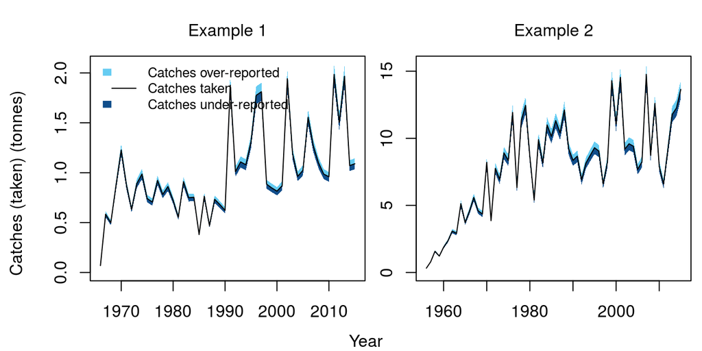

## 5.3 Hyperstability in indices

| Answered |
| --- |
| Strong hyperdepletion (2 < Beta < 3) |
| Hyperdepletion (1.25 < Beta < 2) |
| Proportional (0.8 < Beta < 1.25) |
| Hyperstability (0.5 < Beta < 0.8) |
| Strong hyperstability (0.33 < Beta < 0.5) |

| Justification |
| --- |
| Assessment report do not assume a power function for the catchabilities; but because catchability is very difficult to estimate with certainty, I selected the above three conditions. |

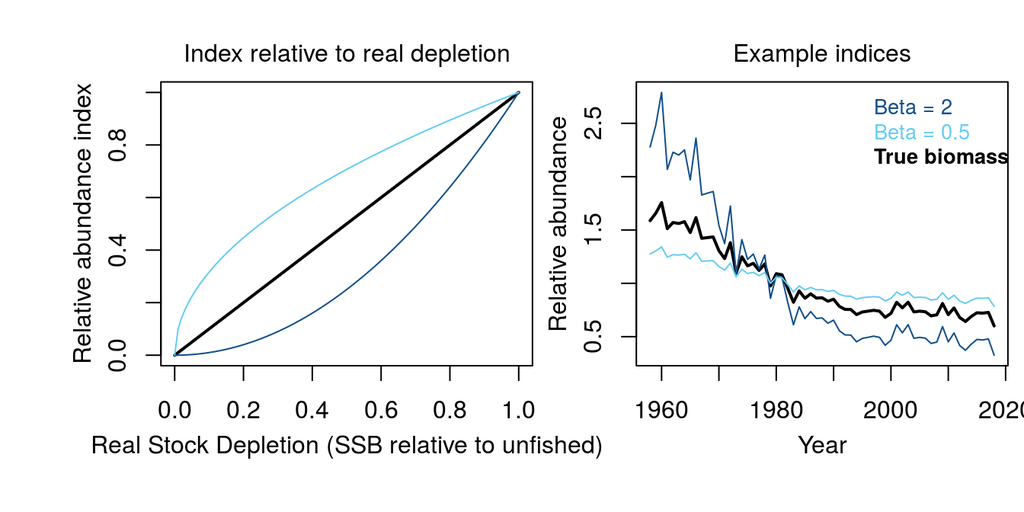

## 5.4 Available data types

| Answered |
| --- |
| Perfect |
| Good (accurate and precise) |
| Data moderate (some what inaccurate and imprecise) |
| Data poor (inaccurate and imprecise) |

| Justification |
| --- |
| No justification was provided |

# 6 Version Notes

The package is subject to ongoing testing. If you find a bug or a problem please send a report to t.carruthers@oceans.ubc.ca so that it can be fixed!

shiny-2019-05-01-19:56:24

Open Source, GPL-2 2019